# Data

## Packages

```r
library(dplyr)
library(sf)
library(purrr)
library(magrittr)
library(lubridate)
library(tidyr)
```

## Selecting the climatic stations

Downloading the polygons of the provinces of Lao PDR from [GADM](https://gadm.org/index.html):

```r
if (!dir.exists("data-raw")) dir.create("data-raw")
file <- "data-raw/gadm36_LAO_1_sf.rds"
if (!file.exists(file))
  download.file("https://biogeo.ucdavis.edu/data/gadm3.6/Rsf/gadm36_LAO_1_sf.rds", file)
```

Loading the polygons of the provinces of Lao PDR:

```r
laos <- readRDS("data-raw/gadm36_LAO_1_sf.rds")
```

Loading the climatic stations:

```r
stations <- readxl::read_excel("/Users/choisy/Dropbox/aaa/R_packages/tutiempo/data-raw/climatic stations.xlsx")
```

Transforming the data frame into an `sf` object:

```r
stations_sf <- stations %>%
  select(-elevation, -from) %>%
  na.exclude() %>%
  st_as_sf(coords = c("longitude", "latitude"), crs = 4326)
```

plotting:

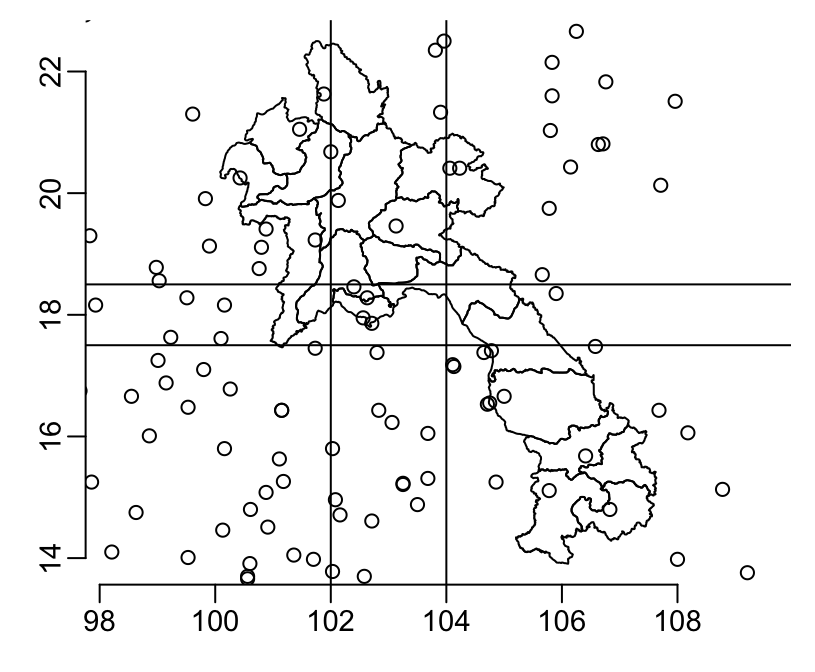

```r
plot(st_geometry(laos))
plot(st_geometry(stations_sf), add = TRUE)
axis(1)
axis(2)
abline(h = 17.5)
abline(h = 18.5)
abline(v = 102)
abline(v = 104)
```

Filtering:

```r
selected_stations <- stations %>%
  filter(102 < longitude, longitude < 104, 17.5 < latitude, latitude < 18.5) %>%
  select(-from)
```

## Downloading the data

The following function removes the last 2 lines of a matrix `m`:

```r
rm_summaries <- function(m) {
  n <- nrow(m)
  m[-((n - 1):n), ]
}
```

The following function coerces a matrix `m` to a data frame using the first line for the variable names:

```r
as.data.frame2 <- function(m) {
  setNames(as.data.frame(m, as.is = TRUE), m[1, ])[-1, ]
}
```

The following function downloads data from the URL `url` and organizes it into a data frame:

```r
get_page <- function(url) {
  require(magrittr) # for the " %>% " operator
  print(url)
  url %>%
    xml2::read_html() %>%
    rvest::html_nodes(".mensuales td , th") %>%
    rvest::html_text() %>%
    matrix(ncol = 15, byrow = TRUE) %>%
    rm_summaries() %>%
    as.data.frame2()
}
```

A safe version of the `get_page()` function, trying the URL again and again if internet is interrupted and handling specific errors (e.g. 404):

```r
safe_get_page <- function(..., error) {
  repeat {
    out <- purrr::safely(get_page)(...)
    if(is.null(out$error) || grepl(error, out$error)) return(out)
  }
}
```

The following function pads 1-digit numbers to 2-digit ones with zeros on the left:

```r
pad <- function(x) {
  stringr::str_pad(as.character(x), 2, pad = "0")
}
```

The following function builds an URL from a year, a month and a station:

```r
make_url <- function(year, month, station) {
  paste0("http://en.tutiempo.net/climate/",
         pad(month), "-", year, "/ws-", station, ".html")
}
```

Here is the main function that downloads the data for the station station:

```r
download_data <- function(station, years, months = 1:12, error = "HTTP error 404") {
  require(magrittr) # for the " %>% " operator
  require(zeallot) # for the " %<-% " operator
  c(months, years) %<-% expand.grid(months, years)
  out <- purrr::map2(years, months, make_url, station = station) %>%
    purrr::map(safe_get_page, error = error) %>%
    purrr::transpose()
  out <- out$result %>%
    setNames(paste(years, pad(months), sep = "-")) %>%
    `[`(sapply(out$error, is.null)) %>%
    dplyr::bind_rows(.id = "ym") %>%
    dplyr::mutate(day = lubridate::ymd(paste(ym, pad(Day), sep = "-"))) %>%
    dplyr::select(-ym, -Day) %>%
    dplyr::select(day, dplyr::everything()) %>%
    dplyr::mutate_if(is.factor, as.character) %>%
    dplyr::mutate_at(dplyr::vars(T, TM, Tm, SLP, PP, VV, V, VM, VG), as.numeric) %>%
    dplyr::mutate_at(dplyr::vars(H), as.integer) %>%
    dplyr::mutate_at(dplyr::vars(RA, SN, TS, FG), function(x) x == "o")
  names(out) %<>%
    sub("^T$", "ta", .) %>%
    sub("TM", "tx", .) %>%
    sub("Tm", "tn", .) %>%
    tolower()
  out
}
```

The following funtion trim errors from a list return from a safe call:

```r
trim_errors <- function(x) {
  lapply(x[which(sapply(x, function(y) is.null(y$error)))], function(y) y$result)
}
```

This function `safely()` calls the above-defined `download_data()` on a dataframe of stations names, year and month values:

```r
make_meteo_data <- function(grid) {
  setNames(with(grid, Map(safely(download_data), station, year, month)),
           apply(grid, 1, paste, collapse = "-")) %>%
  trim_errors() %>%
  bind_rows(.id = "station") %>%
  mutate(station = sub("-\\d*-\\d*$", "", station)) %>%
  split(., .$station) %>%
  lapply(left_join, x = data.frame(day = seq(ymd("2010-01-01"), ymd("2019-05-31"), 1)), by = "day") %>%
  bind_rows() %>%
  mutate_at(station, as.integer) %>%
  select(station, day, everything(), vg) %>%
  arrange(station, day) %>%
  filter(! is.na(station)) %>%
}
```

Downloading the data and writing them to disk:

```r
if (!dir.exists("data")) dir.create("data")
bind_rows(expand.grid(selected_stations$station, 2010:2018, 1:12),
          expand.grid(selected_stations$station, 2019,      1:5)) %>%
  setNames(c("station", "year", "month")) %>%
  make_meteo_data() %>%
  write.csv("data/meteo.csv", quote = FALSE, row.names = FALSE)
```

Writing the stations definitions to disk:

```r
write.csv(selected_stations, "data/stations.csv", quote = FALSE, row.names = FALSE)
```